# Machine Learning Writeup

Brad Hewitt

Wednesday, September 17, 2014

## Summary

This project attempts to predict the manner in which participants performed an exercise. The participants were asked to perform barbell lifts correctly and incorrectly in 5 different ways. The data and further background can be found here: http://groupware.les.inf.puc-rio.br/har. Using a training data set of 19,622 observations, I will use the Random Forest method to create a model that will predict the “classe” used in 20 test observations.

### Study design

First, download the training and test sets from the source. The official training set will not be used until the very end.

```r
set.seed(12322)
# These only need to be run on the first time
# download.file("https://d396qusza40orc.cloudfront.net/predmachlearn/pml-training.csv","trainingdata.csv",method="auto")
# download.file("https://d396qusza40orc.cloudfront.net/predmachlearn/pml-testing.csv","testingdata.csv",method="auto")

trainingdata <- read.csv("trainingdata.csv")
finaltesting <- read.csv("testingdata.csv")
```

Looking at the training data, there are 19,622 observations of 160 variables. This sample set is fairly large, so for the study desing we will spit the training set into training and test groups. We will use this “training” subset to pick features and build the model and use the “testing” subset to estimate the out of sample error rate. The code below separates 80% of the data into the training group and 20% into the testing group. The error rate that will be tested is accuracy.

```r
library(caret);library(ggplot2)
inTrain <- createDataPartition(y=trainingdata$classe, p=.8, list=F)
training <- trainingdata[inTrain,]
testing <- trainingdata[-inTrain,]
```

### Covariate Selection

Building a model with 160 variables would be too resource intensive so we need to eliminate unhelpful variables before training the model.

When reviewing the data, the variables are not all of the same type. There are two columns that are the index number and the user name. Plotting the index and classe shows that the different activity classes were recorded in order.

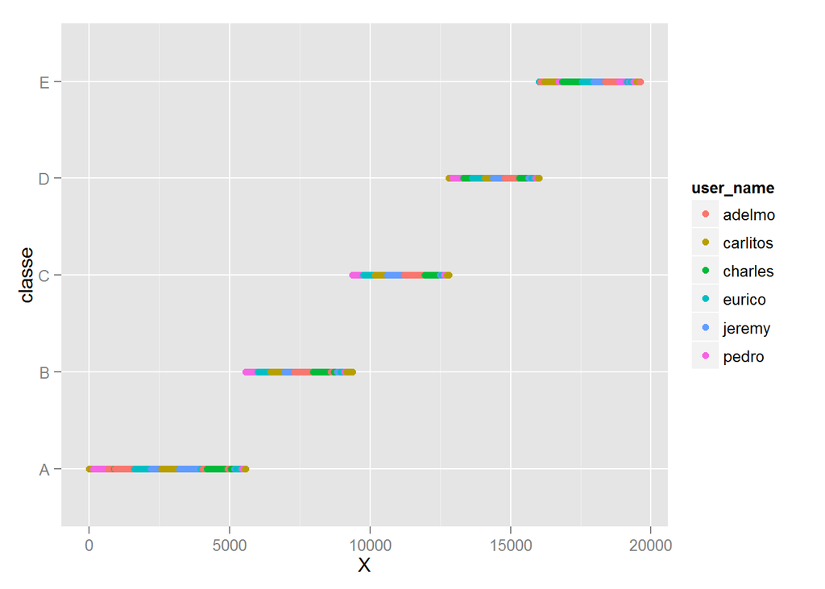

```r
qplot(X,classe, colour = user_name,data=training)
```

There are 3 timestamp variables that appear to be recording when the activites were completed. We will ignore these in the final model.

There also appear to be columns that are summaries or descriptions of the preceding columns. They have names such as “total_accel_belt” which can be interpreted as the total accelaration from the belt sensor. These columns will not be included in the final model. The code below lists the names of the variables, then searches through the names to remove columns with timestamps, index numbers or summary statistics.

```r
names(training)
```

```
##   [1] "X"                        "user_name"
##   [3] "raw_timestamp_part_1"     "raw_timestamp_part_2"
##   [5] "cvtd_timestamp"           "new_window"
##   [7] "num_window"               "roll_belt"
##   [9] "pitch_belt"               "yaw_belt"
##  [11] "total_accel_belt"         "kurtosis_roll_belt"
##  [13] "kurtosis_picth_belt"      "kurtosis_yaw_belt"
##  [15] "skewness_roll_belt"       "skewness_roll_belt.1"
##  [17] "skewness_yaw_belt"        "max_roll_belt"
##  [19] "max_picth_belt"           "max_yaw_belt"
##  [21] "min_roll_belt"            "min_pitch_belt"
##  [23] "min_yaw_belt"             "amplitude_roll_belt"
##  [25] "amplitude_pitch_belt"     "amplitude_yaw_belt"
##  [27] "var_total_accel_belt"     "avg_roll_belt"
##  [29] "stddev_roll_belt"         "var_roll_belt"
```

[output cut: 65 more lines]

```r
sumcols <- grep("X|user_name|timestamp|window|total|kurtosis|skewness|max|min|avg|var|stddev|amplitude",names(training))
trainingclean <- training[,-sumcols]
```

```r
preProc <- preProcess(trainingclean[,-49], method="pca")
```

### Fitting the model

The model fit will use the random forest method, after preprocessing with Principle Component Analysis.

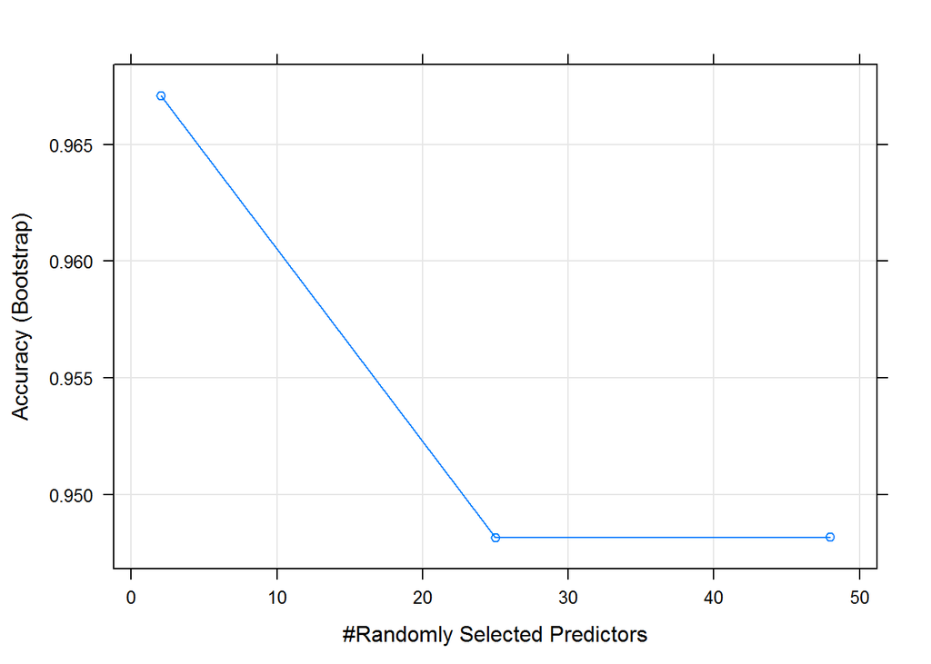

```r
set.seed(12322)
modFit <- train(classe ~ ., data = trainingclean, method = "rf", preProcess = "pca")
plot(modFit)
```

```r
modFit
```

```
## Random Forest
##
## 15699 samples
##    48 predictor
##     5 classes: 'A', 'B', 'C', 'D', 'E'
##
## Pre-processing: principal component signal extraction, scaled, centered
## Resampling: Bootstrapped (25 reps)
##
## Summary of sample sizes: 15699, 15699, 15699, 15699, 15699, 15699, ...
##
## Resampling results across tuning parameters:
##
##   mtry  Accuracy  Kappa  Accuracy SD  Kappa SD
##    2    1.0       1.0    0.003        0.004
##   25    0.9       0.9    0.008        0.010
##   48    0.9       0.9    0.008        0.010
##
## Accuracy was used to select the optimal model using  the largest value.
## The final value used for the model was mtry = 2.
```

Since we set aside a “testing” set earlier, we can apply the model to the test data set to get better estimate of the out of sample accuracy.

```r
confusionMatrix(predict(modFit,testing),testing$classe)
```

```
## Confusion Matrix and Statistics
##
##           Reference
## Prediction    A    B    C    D    E
##          A 1107   15    1    1    0
##          B    7  738    8    3    3
##          C    2    6  668   20    5
##          D    0    0    6  619    0
##          E    0    0    1    0  713
##
## Overall Statistics
##
##                Accuracy : 0.98
##                  95% CI : (0.975, 0.984)
##     No Information Rate : 0.284
##     P-Value [Acc > NIR] : <2e-16
##
##                   Kappa : 0.975
##  Mcnemar's Test P-Value : NA
##
## Statistics by Class:
##
##                      Class: A Class: B Class: C Class: D Class: E
## Sensitivity             0.992    0.972    0.977    0.963    0.989
## Specificity             0.994    0.993    0.990    0.998    1.000
## Pos Pred Value          0.985    0.972    0.953    0.990    0.999
## Neg Pred Value          0.997    0.993    0.995    0.993    0.998
## Prevalence              0.284    0.193    0.174    0.164    0.184
## Detection Rate          0.282    0.188    0.170    0.158    0.182
## Detection Prevalence    0.287    0.193    0.179    0.159    0.182
## Balanced Accuracy       0.993    0.983    0.983    0.980    0.994
```

In this case, the accuracy on the test data is slightly above what it was on the training data. The expected out of sample error is 2%.

### Write the files for submission

The function below creates individual files for the data to be submitted.

```r
pml_write_files = function(x){
  n = length(x)
  for(i in 1:n){
    filename = paste0("problem_id_",i,".txt")
    write.table(x[i],file=filename,quote=FALSE,row.names=FALSE,col.names=FALSE)
  }
}
```

We then take the model and apply it to the final testing data and submit for review.

```r
answers <-as.character(predict(modFit, finaltesting))
pml_write_files(answers)
```